# ps_7

Arnav Srivastava

4/7/2020

## Question 1: Conduct exploratory data analysis

1A) Summary Statistics

Data summary

| Name | Piped data |
| --- | --- |
| Number of rows | 537 |
| Number of columns | 2 |
| _______________________ |  |
| Column type frequency: |  |
| numeric | 2 |
| ________________________ |  |
| Group variables | None |

**Variable type: numeric**

| skim_variable | n_missing | complete_rate | mean | sd | p0 | p25 | p50 | p75 | p100 | hist |
| --- | --- | --- | --- | --- | --- | --- | --- | --- | --- | --- |
| nominate_percentile | 0 | 1 | 49.95 | 28.95 | 0 | 24.81 | 50 | 75 | 100 | ▇▇▇▇▇ |
| age | 0 | 1 | 58.91 | 11.78 | 30 | 50.00 | 59 | 68 | 86 | ▂▅▇▇▂ |

1B) Visualizing a single variable

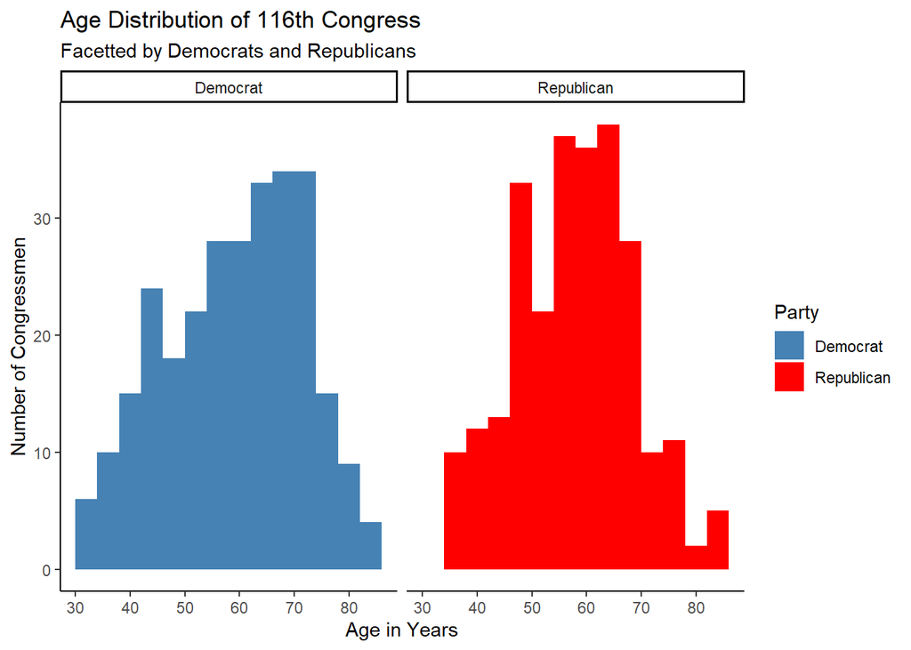

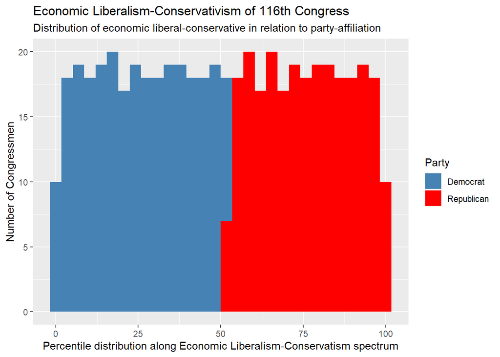

1C) Bivariate Correlations

```
## # A tibble: 1 x 1
##   correlation
##         <dbl>
## 1      -0.159
```

A negative coefficient indicates that as age increases, the nominate_percentile value for a congressmen tends to go decrease (following a straight line), while a positive coefficient indicates that as age increases, the nominate_percentile value for a congressmen tends to go increase (following a straight line).

1D) Plotting Bivariate relationships

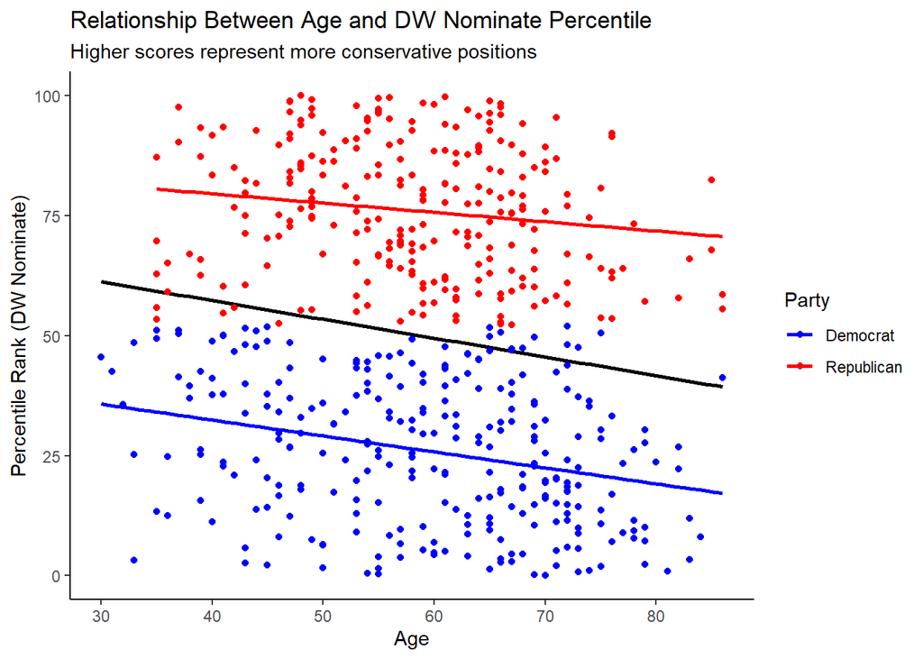

## Question 2: Run a single regression

Effect of Age on DW Nominate Percentile

| Higher percentile suggests more conservative Variable | Higher percentile suggests more conservative Estimate | Higher percentile suggests more conservative Lower bound | Higher percentile suggests more conservative Higher bound |
| --- | --- | --- | --- |
| (Intercept) | 45.7469111 | 37.4458230 | 54.0479993 |
| age | -0.3322965 | -0.4687675 | -0.1958254 |

2B) Interpreting results

The average treatment effect of increasing a congressman’s age by 1 year is -0.33: the effect of a democratic member of Congress being one year older is associated with a their percentile rank for DW nominate scores decreasing by 0.33. We should not necessarily interpret the correlation that older democratic senators are less conservative as causal, as there can be confounding factors. For instance, it is possible that more time spent in Congress makes congressmen more liberal; then, age is not the causal factor of making congressmen less conservative, rather it is the number of years a congressman has spent in Congress which affects how liberal they are. Although it is more likely that incumbent democrats will be older, age is then not the causal factor of growing liberalism, but years spent as an incumbent is the causal factor of growing liberalism. We calculate confidence intervals to determine the strength of our correlation estimate between age and percentile rank. If confidence interval around the estimate was large, then our estimate would be weaker (such that while our estimate is negative, with a large interval upper bound, it is possible that the correlation is actually zero/negative, which changes our interpretation).

2C) Regression and the Rubin Causal Model

We are comparing the potential outcome of conservatism/liberalism for congressmen based on military service (treatment) or no service (control). If the coefficient on military was positive, then the average treatment effect of congress members having served in the military is associated with higher percentile rank for DW nominate scores (more conservative) than control. We can only attribute this difference in potential outcomes to a causal relationship if these results hold in randomized controlled trials, thus accounting for confounding variables and allowing us to truly observe if military service affects liberal/conservative views in congressmen.

## Question 3: Generalize to many regressions

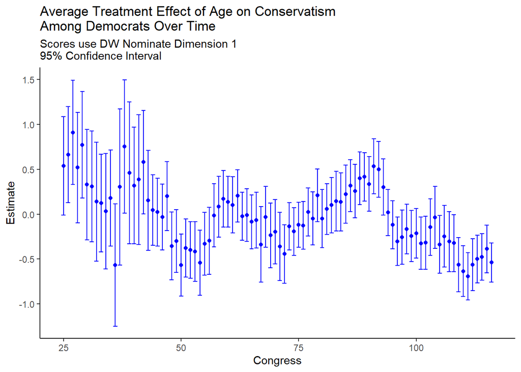

Collaborators: None.